# Contiguous Rain Areas (CRA) Analysis Using R (craR)

National Centre for Medium Range Weather Forecasting (NCMRWF), NOIDA, India

05 July 2024

Contiguous Rain Areas (CRA) is an entity based verifcation method developed by Ebert, E. E., and McBride, J. L. (2000). A CRA is defined for an observation-forecast pair based on user specified rainfall threshold and union of the forecast and observed rain entities. This method quantifies the systematic bias in the model in predicting the rainfall and dissociates it into different error components. The CRA analysis technique is well desribed in Ebert, E. E., and Gallus, W. A. (2009).

A brief summary of the CRA analysis procedure based on the minmization of the mean squared error (MSE) is given below,

- Identification and pairing of the objects: The rainfall objects based on a defined threshold is identified from both forecast and observation using `FeatureFinder` from the `SpatialVx` package. The objects which are close by 5 gridcells are paired and objects which are smaller in area are ignored.
- Calculation of the mean square error and correlation between the identified objects.
- The model field is translated over the CRA until a best match is obtained through the pattern correlation method and where it rotates to get higher pattern correlation and thus quantifies the rotational error
- Each error component is calculated based on Jeremy S. Grams, Willam A. Gallus Jr., Steven E. Koch, Linda S. Wharton, Andrew Loughe, and Elizabeth E. Ebert (2006)

$$\tag{1}
MSE_{Total} = MSE_{Displacement} + MSE_{Volume} + MSE_{Pattern} + MSE_{Rotation}$$

The details on this package and the step-by-step instructions are described below.

**1. CRA Package File System**

**INPUT**

- **obs_20240527.nc :** Test data for observation
- **model_20240527.nc :** Test data for model forecast

**SRC**

- **Isolate_Objects.R :** Function to identify and pair rainfall objects from both model and observation based on rainfall threshold. This will provide each objects in separate NetCDF file.
- **CRA_Err_Decomp_Features.R :** Main function for CRA analysis

**SCRIPTS**

- **For Linux users**
  - *CRA_Calc_Submit.sh* : This is a shell script which creates an R script which does CRA analysis for all the identified model-observation object pairs from the domain. Both of the aforementioned functions are used in this
  - *Run_CRA_Plot.sh* : Creates an R script to plot figures including the necessary statistics tables
- **For Windows users**
  - *TestPlot_CRA.R* : Script to plot figures including the necessary statistics tables after running Isolate_Objects.R and CRA_Err_Decomp_Features.R

**OUTPUT**  
All outputs will be saved in this directory.  
**ReadMe.txt**

This package has been tested on R version 3.4.3 and the list of libraries required for the CRA analysis and plotting are listed below.

```r
library(raster)
library(SpatialVx)

###libraries required for plotting
library(gridExtra)
library(grid)
library(formattable)
library("RColorBrewer")
library(fields)
library(rgdal)
```

**2. Visualization of the input data**  
Read the input data as raster.

```r
orf <- raster("INPUT/obs_20240527.nc")
mrf <- raster("INPUT/model_20240527.nc")
```

To plot the spatial distribution of rainfall from the model and observation

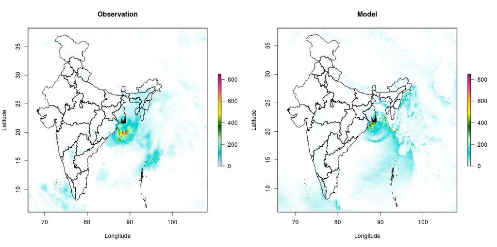

```r
shp <- readOGR(dsn = file.path("SHP/IND_WHOLE.shp"), stringsAsFactors = F)
mycols=c("azure","darkturquoise","darkseagreen1","darkgreen","yellow","goldenrod1","violetred1","maroon4")
myrange=colorRampPalette(mycols)
mycrange=myrange(850)
mycols = mycrange[c(0:850)]
plot(orf, xlim=c(66, 108), ylim=c(6, 38), zlim=c(0,850), xlab = "Longitude",
     ylab = "Latitude", interpolate=TRUE, col=mycols, xaxs="i", yaxs="i",
     asp=1, legend=TRUE, main="Observation")
plot(shp,add=TRUE)

plot(mrf, xlim=c(66, 108), ylim=c(6, 38), zlim=c(0,850), xlab = "Longitude",
     ylab = "Latitude", interpolate=TRUE, col=mycols, xaxs="i", yaxs="i",
     asp=1, legend=TRUE, main="Model")
plot(shp,add=TRUE)
```

**3. CRA Analysis**

**3.1. Regrid Input Data and Isolate Rainfall Objects**  
Primarily, the resolution and data extents of both model and observed data are checked and regrids. To identify the rainfall objects from model and observation, a threshold rainfall has to be defined in mm/day. In this test case threshold is fixed as 40 mm/day based on which the rainfall objects are identified. The function `Isolate_Objects` regrids, identifies the rainfall objects and save them into NetCDF format. The parameters ‘minsize’ and ‘sepdist’ make the verification field more precise with exclusion of rainfall objects of lesser area and merges only the objects close by 5 grid points. These valuse are tunable based on the threshold we consider. The ‘minsize’ can be lesser for higher threshold. More details on the input arguments are given in Annexure.

```r
source("SRC/Isolate_Objects.R")
Isolate_Objects("INPUT/obs_20240527.nc","INPUT/model_20240527.nc","OUTPUT/Obj_Obs_Th40","OUTPUT/Obj_Model_Th40",thr=40,minsize=5,sepdist=5)
```

The isolated objects are saved with the prefix ‘Obj_Obs_Object’ and ‘Obj_Model_Object’ from observation and model forecast respectively.

**3.2. Error decomposition**  
Using the aforementioned object files from model and observation the error components are calculated using `CRA_Err_Decomp` function. More details on the input arguments are given in Annexure.  
Example for the first object of this test case is shown below

```r
source("SRC/CRA_Err_Decomp_Features.R")
CRA_Err_Decomp("INPUT/obs_20240527.nc","INPUT/model_20240527.nc","OUTPUT/Obj_Obs_Th40_Object1.nc","OUTPUT/Obj_Model_Th40_Object1.nc",thr=40,objnum=1,"OUTPUT/20240527_Thr40_NCUMG_day1",Ngrids=6,iopt=2)
```

The `CRA_Err_Decomp_Features.R` produces a set of ASCII files alongwith the modified model data after shift and rotation of the rainfall object done for maximum overlap. The files created for the object 1 of the sample data are given below

- **20240527_Thr40_NCUMG_day1_1_Table1.txt :** Characteristics of extracted rainfall objects i.e., no. of points, average rainfall, maximum rainfall, and rain volume from model and observation
- **20240527_Thr40_NCUMG_day1_1_Table2.txt :** RMSE and correlation calculated between model and observation from actual, shifted model rainfall field and shifted+rotated model rainfall field
- **20240527_Thr40_NCUMG_day1_1_Table3.txt :** CRA error components (%)
- **20240527_Thr40_NCUMG_day1_1_Table4.txt :** Location error in terms of longitude, latitude and angle of rotation
- **20240527_Thr40_NCUMG_day1_1_ScatterData.txt :** Data to plot scatter diagram between observation and modified model rainfall
- **20240527_Thr40_NCUMG_day1RotatedModel_1.nc :** Rotated model field data at the angle of maximum overlap

**4. Plotting the statistics**  
The final CRA plot with all the statistics actual, after the shift, and after shift and rotation of the model raster over the CRA area can be plotted using `Run_CRA_Plot.sh`. The arguments to be given to this script are: date, Object number, experiment name (here, 20240527_Thr40_Test), output path, and threshold chosen

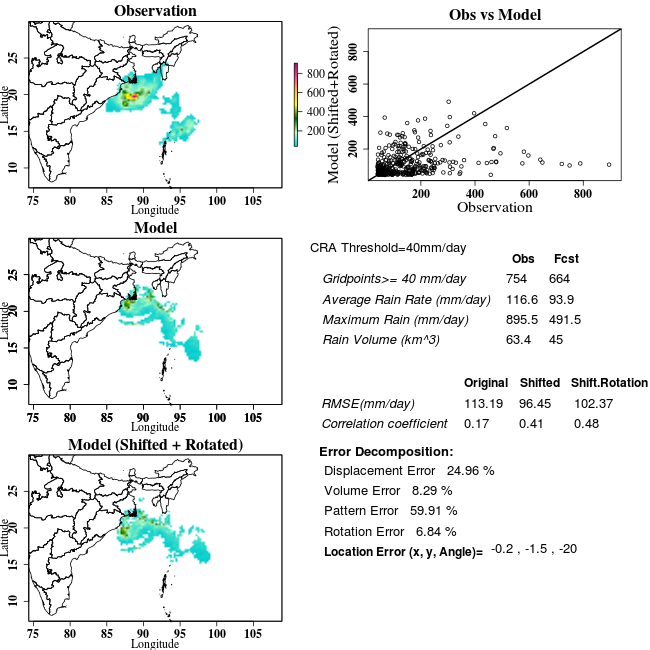

**5. CRA Analysis for multiple objects**  
One can use `CRA_Calc_Submit.sh`, if multiple paired objects are to be analysed which are identified over the same domian. More details on this script can be found in ReadMe.txt.

**6. Annexure**

**Isolate_Objects(ActOrf,ActMrf,objOBS,objMODEL,thr,minsize,sepdist)**  
*User inputs for this function are:*  
ActOrf : Actual observation  
ActMrf : Actual model  
objOBS : prefix for the object NetCDF file from observation  
objMODEL: prefix for the object NetCDF file from model  
thr : Threshold rainfall  
minsize : The minum area of the object to be considered for the analysis. At present it is kept as 5  
sepdist : The minimum number of grids in between the objects to be considered for merging the objects. At present it is kept as 5  
**CRA_Err_Decomp(ActOrf,ActMrf,orf,mrf,thr,objnum,out_prefix,Ngrids,iopts)**  
*User inputs for the function are:*  
ActOrf : Actual observation  
ActMrf : Actual model  
orf : object1 from observation  
mrf : object1 from model  
thr : Threshold rainfall  
objnum : serial number of the object  
out_prefix: prefix of the output file  
Ngrids :number of grids of model translation over CRA area. At present it is kept as 6  
iopts : Whether to include rotational error component or not. iopts=1 gives error decomposition without rotation and iopt=2 gives error decomposition with rotation

**7. References:**

Dube, A., Karunasagar, S., Ashrit, R., and Mitra, A. K. 2022. “Spatial Verification of Ensemble Rainfall Forecasts over India.” https://doi.org/10.1016/j.atmosres.2022.106169.

Ebert, E. E., and Gallus, W. A. 2009. “Towards Better Understanding of Contiguous Rain Areas (Cra) Method of Spatial Verification.” https://doi.org/10.1175/2009WAF2222252.1.

Ebert, E. E., and McBride, J. L. 2000. “Verification of Precipitation in Weather Systems: Determination of Systematic Errors.” https://doi.org/10.1016/S0022-1694(00)00343-7.

Jeremy S. Grams, Willam A. Gallus Jr., Steven E. Koch, Linda S. Wharton, Andrew Loughe, and Elizabeth E. Ebert. 2006. “The Use of a Modified Ebert-Mcbride Technique to Evaluate Mesoscale Model Qpf as a Function of Convective System Morphology During Ihop 2002.” https://doi.org/10.1175/WAF918.1.

Sharma, K., Ashrit, R., Ebert, E., Iyengar, G., and Mitra, A. 2015. “NGFS Rainfall Forecast Verification over India Using the Contiguous Rain Area (Cra) Method.” https://doi.org/10.54302/mausam.v66i3.551.

Sharma, K., Ashrit, R., Ebert, E., Mitra, A., Bhatla, R., Iyengar, G., and Rajagopal, E. N. 2019. “Assessment of Met Office Unified Model (Um) Quantitative Precipitation Forecasts During the Indian Summer Monsoon: Contiguous Rain Area (Cra) Approach.” https://doi.org/10.1007/s12040-018-1023-3.